# What is the IRF1 consensus binding motif?

Axel Nohturfft

31-January-2017

## Introduction:

Searching for common DNA sequence elements among a set of promoters of ChIP-seq peaks is a common task in functional genomics.  
As with the last session, we will begin our analyses with a large table of chip-seq data from the ENCODE project. This so-called ‘summary track’ is a table that contains processed peak locations for 161 transcription factors from 91 different cell lines.  
This time we will extract the peaks for the transcription factor IRF1 and then search the peak sequences for common sequence motifs.  
Any motifs returned by this search will be compared against the JASPAR database of known transcription factor binding sites.

## Setting things up…

### Clear memory and console

```r
rm(list=ls(all=T)) # clear memory
cat("\014") # clear console
```

```r
options(stringsAsFactors = FALSE)
```

### Parameters:

```r
tf <- "IRF1"
expcount.min <- 4
score.min <- 700
```

### Load Packages

To get a list of all the functions and data provided by a specific package type for example `help(package="ChIPpeakAnno")`. On [CRAN](http://cran.r-project.org/web/packages/) and [Bioconductor](http://www.bioconductor.org/) you will also find detailed manuals and often so-called ‘Vignettes’ that provide worked examples.

The rGADEM package provides tools to search for common motifs among a set of DNA sequences. For help about the rGADEM package, type: `help(package="rGADEM")`.

The ‘BSgenome.Hsapiens.UCSC.hg19’ package provides the complete genome sequences for Homo sapiens (UCSC version hg19). This package is essential to obtain the DNA sequences that correspond to the peak coordinates from ENCODE. Loading this library creates a BSgenome object ‘Hsapiens’ that we will use later with rGADEM.

BSgenome packages for other genomes can be found with the following command: `BSgenome::available.genomes()`.

```r
pkg.lib <- "/homedirs18/sghms/bms/shares/bdib/BDiB_2017_18/Session_08/Session_08_R/packages"
stopifnot(file.exists(pkg.lib))
list.files(pkg.lib)
```

```
 [1] "annotate"                    "AnnotationDbi"               "Biobase"                     "BiocGenerics"
 [5] "BiocParallel"                "Biostrings"                  "BSgenome"                    "BSgenome.Hsapiens.UCSC.hg19"
 [9] "CNEr"                        "curl"                        "DBI"                         "DelayedArray"
[13] "futile.logger"               "futile.options"              "GenomeInfoDb"                "GenomeInfoDbData"
[17] "GenomicAlignments"           "GenomicRanges"               "GO.db"                       "hms"
[21] "httr"                        "IRanges"                     "JASPAR2014"                  "KEGGREST"
[25] "lambda.r"                    "magrittr"                    "openssl"                     "pkgconfig"
[29] "png"                         "poweRlaw"                    "R6"                          "RCurl"
[33] "readr"                       "rGADEM"                      "rlang"                       "Rsamtools"
[37] "rtracklayer"                 "S4Vectors"                   "seqLogo"                     "snow"
[41] "SummarizedExperiment"        "TFMPvalue"                   "VGAM"                        "XML"
[45] "XVector"                     "zlibbioc"
```

```r
# pkg.lib <- "/usr/lib64/R/library"
# pkg.lib <- "packages"
.libPaths(pkg.lib)
.libPaths()
```

```
[1] "/homes/homedirs18/sghms/bms/shares/bdib/BDiB_2017_18/Session_08/Session_08_R/packages"
[2] "/usr/lib64/R/library"
[3] "/usr/share/R/library"
```

```r
library(magrittr, lib.loc=pkg.lib)
library(readr, lib.loc=pkg.lib)
library(rGADEM, lib.loc=pkg.lib)
# library(MotIV, lib.loc=pkg.lib)
library(JASPAR2014, lib.loc=pkg.lib)
# library(TFBSTools, lib.loc=pkg.lib)
library(BSgenome.Hsapiens.UCSC.hg19, lib.loc=pkg.lib)
```

### Script name + working directory

```r
adc <- rstudioapi::getActiveDocumentContext()
pfad <- strsplit(adc$path, split="/")[[1]]
this.script <- pfad[length(pfad)]
wd <- paste(pfad[-length(pfad)], collapse="/")
setwd(wd)
rm(adc, pfad)
cat("**Working directory:**", wd, "\n**Script name:**", this.script, sep="\n")
```

```
**Working directory:**
~/_BDiB/BDiB_2017_18/Session_08/bdib_chipseq_2018

**Script name:**
01-ENCODE_stat1.Rmd
```

## Read and prepare ChIP-seq peak data from ENCODE

The dataset from ENCODE that we’ll use for this tutorial is a “summary track” that contains the ChIP-seq peak data compiled from many experiments, using a large number of antibodies and cell lines. This summary track was designed to display ChIP-seq peaks in the UCSC Genome Browser, but is also an excellent resource for data mining.  
The original ENCODE track was downloaded from this site: http://hgdownload.cse.ucsc.edu/goldenpath/hg19/encodeDCC/wgEncodeRegTfbsClustered/  
… and is described here:  
http://genome.ucsc.edu/cgi-bin/hgTrackUi?db=hg19&g=wgEncodeRegTfbsClusteredV3

Column headers:  
bin chrom chromStart chromEnd name score expCount expNums expScores

The ‘.gz’ extension of the data file name indicates that the file has been compressed (the current file size is 85MB; uncompressed it would be 256MB!). Conveniently, R opens gzip-compressed files without needing special instructions.

### Read data file:

(This can take a moment …)

```r
data.file <- paste0(pkg.lib, "/Session_04_Motif_Search_FOXP2_2017.Rmd.df.rds")
data.file
```

```
[1] "/homedirs18/sghms/bms/shares/bdib/BDiB_2017_18/Session_08/Session_08_R/packages/Session_04_Motif_Search_FOXP2_2017.Rmd.df.rds"
```

```r
stopifnot(file.exists(data.file))
```

```r
pryr::object_size(df) #%>% format(big.mark=",") %>% cat(., "bytes")
```

```
312 MB
```

### Add column headers to chip-seq data frame:

Based on [track information](http://genome.ucsc.edu/cgi-bin/hgTrackUi?db=hg19&g=wgEncodeRegTfbsClusteredV3) from ENCODE we now assign descriptive column headers to the data frame …

```r
names(df) <- c("chrom", "chromStart", "chromEnd", "name", "score", "expCount", "expNums", "expScores")
print(head(df))
```

|  | chrom | chromStart | chromEnd | name | score | expCount | expNums | expScores |
| --- | --- | --- | --- | --- | --- | --- | --- | --- |
| 1 | chr1 | 10073 | 10329 | ZBTB33 | 354 | 2 | 204,246 | 354,138 |
| 2 | chr1 | 10149 | 10413 | CEBPB | 201 | 1 | 343 | 201 |
| 3 | chr1 | 16110 | 16390 | CTCF | 227 | 7 | 213,612,621,627,628,631,662 | 110,139,171,209,227,200,170 |
| 4 | chr1 | 29198 | 29688 | TAF1 | 184 | 1 | 157 | 184 |
| 5 | chr1 | 29275 | 29591 | GABPA | 198 | 1 | 180 | 198 |
| 6 | chr1 | 89795 | 90051 | USF1 | 185 | 2 | 68,202 | 146,185 |

According to the ENCODE info, the dataset should store peak coordinates for 161 DNA binding proteins. Check:

```r
df$name %>% as.character %>% unique %>% length %>% cat
```

```
161
```

```r
df$name %>% as.character %>% unique %>% sort %>% cat(sep=", ")
```

```
ARID3A, ATF1, ATF2, ATF3, BACH1, BATF, BCL11A, BCL3, BCLAF1, BDP1, BHLHE40, BRCA1, BRF1, BRF2, CBX3, CCNT2, CEBPB, CEBPD, CHD1, CHD2, CREB1, CTBP2, CTCF, CTCFL, E2F1, E2F4, E2F6, EBF1, EGR1, ELF1, ELK1, ELK4, EP300, ESR1, ESRRA, ETS1, EZH2, FAM48A, FOS, FOSL1, FOSL2, FOXA1, FOXA2, FOXM1, FOXP2, GABP…
```

## Extract relevant peaks from the track data

### Extract data specific for IRF1

Then print the number of IRF1 peaks.

```r
irf1 <- subset(df, name==tf)
nrow(irf1) %>% format(big.mark=",") %>% cat
```

```
20,215
```

```r
# FOXP2: 27,652
# STAT1: 19,147
```

```r
# Clear some memory by removing the original data frame
# rm(df)
# gc(verbose = FALSE)
```

Given a vector of numbers the `range()` function returns the highest and lowest of the numbers:

```r
range(irf1$expCount)
```

```
[1] 1 4
```

```r
# MYC: 1 21
# FOXP2: 1 2
# STAT1L 1 6
```

#### Draw a histogram of the IRF1 peak scores

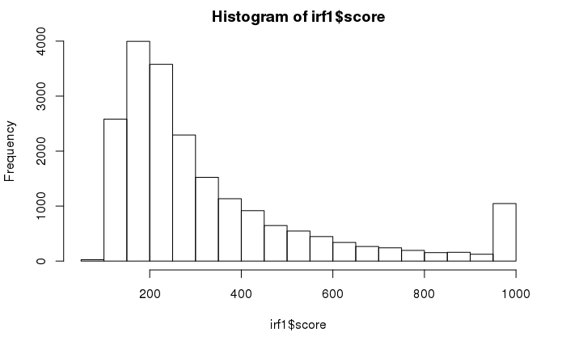

```r
hist(irf1$score)
```

### Some filtering:

Keep only peaks found in a minimum number of experiments and with a minimum score.

Minimum number of experiments (defined at start of script):

```r
cat(expcount.min)
```

```
4
```

```r
stopifnot(expcount.min <= max(irf1$expCount))
```

Minimum score (defined at start of script):

```r
cat(score.min)
```

```
700
```

```r
# The line of code will give an error if the expcount.min is too large
stopifnot(expcount.min <= max(irf1$score))
```

```r
# expcount.min <- 5
# score.min <- 700
irf1.b <- subset(irf1, expCount >= expcount.min)
irf1.c <- subset(irf1.b, score >= score.min) # MYC: 1000; FOXP2: 700; stat1: 700
nrow(irf1.c) %>% cat("Number of remaining peaks:", .)
```

```
Number of remaining peaks: 163
```

## Get DNA sequence for each peak

```r
chr <- irf1.c$chrom
start <- irf1.c$chromStart
end <- irf1.c$chromEnd
seq.ds <- Biostrings::getSeq(Hsapiens, names=chr, start=start, end=end)
rm(chr, start, end)
class(seq.ds)
```

```
[1] "DNAStringSet"
attr(,"package")
[1] "Biostrings"
```

Let’s have a look. By default `print()`’ing shows the fist nd last nucleotides of a sequence, and the first and last 5 sequences of a set:

```r
print(seq.ds)
```

```
  A DNAStringSet instance of length 163
      width seq                                                                                                            names
  [1]   469 CCATGGGGATGTTTTCCAAGTTTACTAATTTTGCAAGTTGGTAAATGGAAAATG...CCCACAGCCCACAGCCCACAGCCATGGTAAGGCAGATGTCACAGGTGGGGGGA chr1
  [2]   398 CAATGCTGCCCCCACCAGGGCTGCTTTCCCAGGAATCCTGTGACCAGCAAGGGA...AAATAACAAGTCCTAAAAGGACAAGTCCTCTCACCTATGTGCAAAAAGAAAGA chr1
  [3]   361 GAGAAGCAATCTTCAGCCCGGAGCCTGCTGATAGATGGGCACAGCAGCGAGTAA...ATTCAAAGCATGTCACACTATGATGAGAGCCACGGCCATACTGGGCTTAGTGA chr1
  [4]   400 TGAGTGTAAACCTCAGTGTGTGGCTGGGCAGCTGTCAAGAAAGCCACCTGAACA...CCTCTGATGAAAAGAATATGGCAAATATGATGGGACGCCGCTTCTAAGACTCA chr1
  [5]   471 TTTAAAACATTCCACTCCGGAAATGCCAGAGGGCTGGCAAAGACACTACGGTTA...GAGGTAGGACGCCAGCAGCCAGGCTCTTAACACTCAGGAAGGGTGGTGCCTCC chr1
  ...   ... ...
[159]   467 TGAATACATAGTGCTGTTTTAAGTTATTTGTGTGTTATGAAGAAAAGGTCACTA...TGTTATTTAAAGCACTTGATGCTAGCTTGTGATGATGAGTGATGGGGTGCAGT chr9
[160]   395 CATAGCAACTGGGCTGCATCTAAAAGGGAAGAATCAAGGGCGTGATCCACAACC...CTTCTAGAGACCACTCTAGTGGCTCGGCAGCCTTGGTATAGAGCTGATGATAA chr9
[161]   555 TCAATATCACTTTTGAAAAAGGCTTTCGCTGTTCTCAGCAGCGTCCGCATTTGT...GGCGCGCTGTAGGCCCCGGGTCGCCAGGGTCGCTGGCGTCTGGGTCCCGGGAC chr9
[162]   379 CACATTCAGCTTCCTTCCTACTTTAAGCTGGCTTAATTGCATATACTTTCAACA...TAGGAGGAGCTTATGGGGACAAATTGATTGGAAGGAGTGGGAGTAAGATTTGA chr9
[163]   509 CCAGCAGTGGCCTTACCCTGCTCTCAGGGATGGGACTCTCAGATGGAGCCAAGC...TCTGCGTGTTGTGGGTGGTCACACCCAGGCCTGCCTCCCACAGCCCCAGCCCT chrX
```

## Search for common DNA motifs

Motif search - key input for the `GADEM()` function:

1. Sequences in “DNAStringSet” format
2. a BSgenome object (here for Hsapiens)

The code below can take a long time to execute if the number of peaks is large.

```r
gadem.results <- rGADEM::GADEM(seq.ds, verbose=TRUE, genome=Hsapiens)
```

```
*** Start C Programm ***
==============================================================================================
input sequence file:
number of sequences and average length:             163 432.5
Use pgf method to approximate llr null distribution
parameters estimated from sequences in:

number of GA generations & population size:         5 100

PWM score p-value cutoff for binding site declaration:      2.000000e-04
ln(E-value) cutoff for motif declaration:           0.000000

number of EM steps:                     40
minimal no. sites considered for a motif:           8

[a,c,g,t] frequencies in input data:                0.233974 0.266026 0.266026 0.233974
==============================================================================================
*** Running an unseeded analysis ***
GADEM cycle  1: enumerate and count k-mers... top 3  4, 5-mers: 20 40 60
Done.
Initializing GA... Done.
GADEM cycle[  1] generation[  1] number of unique motif: 4
   spacedDyad: aaatnnnnnnnnctctg    motifConsensus: nnsTTTCwsTTTCnnTy     0.80 fitness: -299.04
   spacedDyad: gagnnnnnnnnnnctggg   motifConsensus: sGGnrGGmGGrGsnrsGG    1.00 fitness:  -93.60
   spacedDyad: ggannnnnnnnnggaaa    motifConsensus: GGAAGGGrrrvrGrAAG     0.10 fitness:   -9.21
   spacedDyad: tccccct              motifConsensus: yCCTCCC               0.60 fitness:   -6.58

GADEM cycle[  1] generation[  2] number of unique motif: 5
   spacedDyad: aaatnnnnnnnnctctg    motifConsensus: nnsTTTCwsTTTCnnTy     0.80 fitness: -299.04
   spacedDyad: gagnnnnnnnnnnctggg   motifConsensus: sGGnrGGmGGrGsnrsGG    1.00 fitness:  -93.60
   spacedDyad: tctctnnnnnnnnnncct   motifConsensus: yyyCykyywCyyTyyyyy    0.40 fitness:  -61.78
   spacedDyad: ctgnngagg            motifConsensus: GGGAGGArG             0.60 fitness:  -38.83
   spacedDyad: tggnnnntttt          motifConsensus: TTTkTTTTyyT           0.50 fitness:   -4.67

GADEM cycle[  1] generation[  3] number of unique motif: 5
   spacedDyad: aaatnnnnnnnnctctg    motifConsensus: nnsTTTCwsTTTCnnTy     0.80 fitness: -299.04
   spacedDyad: gagnnnnnnnnnnctggg   motifConsensus: sGGnrGGmGGrGsnrsGG    1.00 fitness:  -93.60
   spacedDyad: tctctnnnnnnnnnncct   motifConsensus: yyyCykyywCyyTyyyyy    0.40 fitness:  -61.78
   spacedDyad: ctgnngagg            motifConsensus: GGGAGGArG             0.60 fitness:  -38.83
   spacedDyad: tctctnnnnnnnnnnaaaca motifConsensus: TTTyTTTyTTkTwTTnwwyn  0.40 fitness:  -32.55
```

[output cut: 17 more lines]

```
Initializing GA... Done.
GADEM cycle[  2] generation[  1] number of unique motif: 1
   spacedDyad: tccnnnnnnnngcctg     motifConsensus: nyCCrGssyCykCCws      0.50 fitness:   20.41

GADEM cycle[  2] generation[  2] number of unique motif: 1
   spacedDyad: agagnnnnnnnaag       motifConsensus: GGAGsCTsnrGrrG        0.90 fitness:   20.36

GADEM cycle[  2] generation[  3] number of unique motif: 1
   spacedDyad: agagnnnnnnnaag       motifConsensus: GGAGsCTsnrGrrG        0.90 fitness:   20.36

GADEM cycle[  2] generation[  4] number of unique motif: 1
   spacedDyad: agagnnnnnnnaag       motifConsensus: GGAGsCTsnrGrrG        0.90 fitness:   20.36

GADEM cycle[  2] generation[  5] number of unique motif: 1
   spacedDyad: agagnnnnnnnaag       motifConsensus: GGAGsCTsnrGrrG        0.90 fitness:   20.36
```

```r
# class(gadem.results) # "gadem" (rGADEM)
```

### Save rGadem results

```r
file.name.1 <- paste0(this.script, ".RDS")
saveRDS(object=gadem.results, file=file.name.1, compress="bzip2")
system(paste("du -h", file.name.1), intern=TRUE) %>% cat
```

```
12K 01-ENCODE_stat1.Rmd.RDS
```

### Extract position weight matrices from GADEM results:

```r
pwm.list <- getPWM(gadem.results)
length(pwm.list) %>% cat("Number of motifs found:", ., "\n")
```

```
Number of motifs found: 2
```

```r
# stat1: Number of motifs found: 3
```

What kind of object is pwm.list?

```r
class(pwm.list)
```

```
[1] "list"
```

List items can have names. Name the motifs:

```r
names(pwm.list) <- paste0("Motif", 1:length(pwm.list))
lapply(pwm.list, class)
```

```
$Motif1
[1] "matrix"

$Motif2
[1] "matrix"
```

What kind of objects are the list items?

```r
sapply(pwm.list, class)
```

```
  Motif1   Motif2
"matrix" "matrix"
```

A position weight matrix (PWM) gives the relative frequencies for each of the four bases for the positions of a motif.  
We extract items from a list (subsetting) using double square brackets.

First motif:

```r
pwm.list[[1]]
```

```
       1      2      3      4      5      6      7      8      9     10     11     12     13     14     15     16
A 0.0545 0.0113 0.0005 0.0005 0.0149 0.4833 0.0365 0.0113 0.0077 0.0437 0.0221 0.2707 0.1086 0.1410 0.0906 0.0798
C 0.4617 0.0798 0.0545 0.0798 0.7319 0.0617 0.4545 0.0005 0.0834 0.0185 0.7319 0.2311 0.3356 0.1770 0.1842 0.3103
G 0.3320 0.0221 0.0221 0.0221 0.0149 0.1878 0.2779 0.0041 0.0041 0.0077 0.0293 0.2023 0.1987 0.0257 0.0509 0.1230
T 0.1518 0.8868 0.9228 0.8976 0.2383 0.2671 0.2311 0.9841 0.9048 0.9300 0.2167 0.2959 0.3572 0.6562 0.6742 0.4869
```

Second motif:

```r
pwm.list[[2]]
```

```
       1      2      3      4      5      6      7      8      9     10     11     12     13     14     15     16     17     18
A 0.0100 0.2039 0.0052 0.0052 0.0005 0.0714 0.0147 0.0100 0.0951 0.0052 0.0052 0.0809 0.0147 0.0100 0.0525 0.0100 0.1755 0.2096
C 0.9039 0.3032 0.5870 0.9559 0.4971 0.6201 0.5965 0.7005 0.5586 0.8046 0.5823 0.4262 0.6863 0.6580 0.5350 0.7336 0.7762 0.3284
G 0.0573 0.0762 0.3978 0.0100 0.2086 0.0052 0.1424 0.0809 0.0856 0.0667 0.0194 0.2796 0.1093 0.0100 0.1235 0.0289 0.0241 0.2381
T 0.0289 0.4167 0.0100 0.0289 0.2938 0.3032 0.2465 0.2086 0.2606 0.1235 0.3931 0.2133 0.1897 0.3221 0.2890 0.2275 0.0241 0.2239
```

Third motif: not applicable for IRF1

```r
pwm.list[[3]]
```

```
Error in pwm.list[[3]] : subscript out of bounds
```

### Plot sequence logos of motif(s) found by rGADEM:

**MOTIF 1**

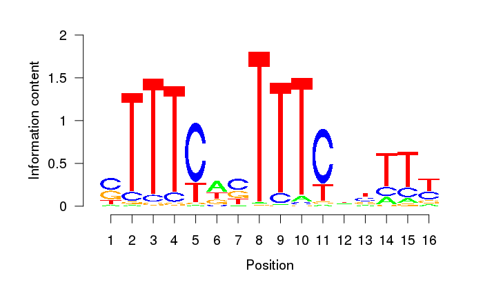

```r
seqLogo::seqLogo(pwm.list[[1]])
```

Plot sequence logo for Motif 1 in the reverse complement orientation:

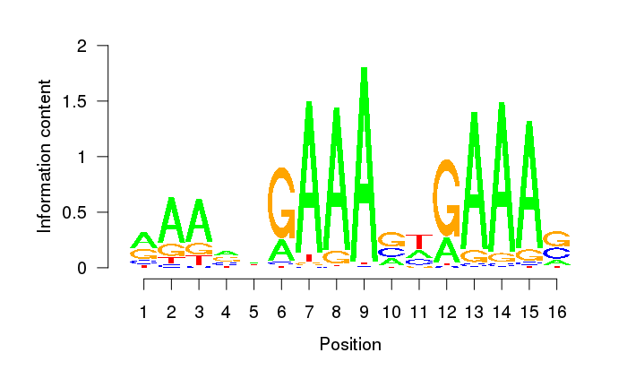

```r
seqLogo::seqLogo(reverseComplement(pwm.list[[1]]))
```

**MOTIF 2**

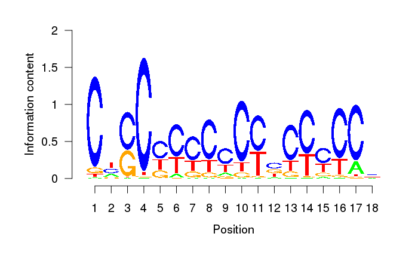

```r
seqLogo::seqLogo(pwm.list[[2]])
```

Motif 2 in reverse complement orientation:

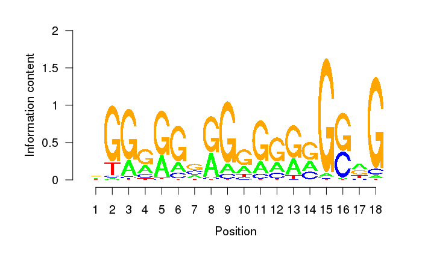

```r
seqLogo::seqLogo(reverseComplement(pwm.list[[2]]))
```

**MOTIF 3**

```r
# seqLogo::seqLogo(pwm.list[[3]])
```